# SAGES - Predicting GCP slope

Author

Doug Tommet

Published

February 15, 2024

# Goals

## Overall goal

The overall goal is to build the two best prediction models for delirium and cognitive decline as possible given the data we collected. This is intended for a research audience because many of the variables going into this model would be difficult for clinicians to obtain.

## Today’s (2024-02-02) goal

Review the variables that made it through our selection process for inclusion into the model.

# Background

There are many interesting variables that could possibly included in our model. There are too many to reasonably include in any type of model given our sample size. So, we need a process to trim down our candidate variable list. The process we will use involves two (three?, four?) steps.

1. Variables with more than 50% missingness will be dropped. Those with less than 50% missingness will have values imputed using predictive mean matching.
2. Variables that lack any variability will be dropped. If a variable is an indicator for whether something happened, and only a few participants experienced the event, then even if the indicator is clinically meaningful, it will be dropped because it will make a poor predictor in the model.
3. Variables that are redundant with each other will be dropped. If a variable that can be reasonably well predicted by other variables in the model, then that variable is not providing much more to the model.
4. The remaining variables will be combined into principal components.

# The data

The data comes from the patient interview, the medcial record review, including lab values and peri-operative data.

# Summary of lab values

## Missing values

These are the lab values that were dropped for having more than 50% missing values:

| **Characteristic** | **N = 560**<sup>1</sup> |
| --- | --- |
| ALT (IU/L) (Pre-op) | 20 (9) |
| Unknown | 375 |
| AST (IU/L) (Pre-op) | 22.6 (7.8) |
| Unknown | 377 |
| Bilirubin (mg/dL) (Pre-op) | 0.45 (0.23) |
| Unknown | 403 |
| Albumin (g/dL) (Pre-op) | 4.24 (0.38) |
| Unknown | 404 |
| ABG: pH (POD1) | 7.37 (0.09) |
| Unknown | 534 |
| p02 (mmHg) (POD1) | 165 (82) |
| Unknown | 533 |
| pCO2 (mmHg) (POD1) | 41 (7) |
| Unknown | 534 |

<sup>1</sup> Mean (SD)

Imputation was done on the remaining lab values using predictive mean matching.

## Indicator variables

Indicator variables for low and high values were created for the lab values.

This section provides summary statistics of whether the lab values met a clinically relevant cutoff.

## Pre-op labs

### Pre-op labs - any abnormality

Note: BUN/CRE ratio and Anion Gap thresholds were not updated and used values from previous work.

| **Characteristic** | **N = 560**<sup>1</sup> |
| --- | --- |
| Abnormal labs: WBC <= 2 or WBC >= 15 (Pre-op) |  |
| WBC normal | 555 (99%) |
| WBC abnormal | 5 (0.9%) |
| Abnormal labs: HCT <= 21 or HCT >= 62 (Pre-op) |  |
| HCT normal | 560 (100%) |
| HCT abnormal | 0 (0%) |
| Abnormal labs: BUN >= 50 (Pre-op) |  |
| BUN normal | 554 (99%) |
| BUN abnormal | 6 (1.1%) |
| Abnormal labs: CRE >= 5 (Pre-op) |  |
| CRE normal | 560 (100%) |
| CRE abnormal | 0 (0%) |
| Abnormal labs: SOD <= 120 or SOD >= 160 (Pre-op) |  |
| SOD normal | 560 (100%) |
| SOD abnormal | 0 (0%) |
| Abnormal labs: POT <= 2.9 or POT >= 6.0 (Pre-op) |  |
| POT normal | 557 (99%) |
| POT abnormal | 3 (0.5%) |
| Abnormal labs: CHL <= 85 or CHL >= 115 (Pre-op) |  |
| CHL normal | 560 (100%) |
| CHL abnormal | 0 (0%) |
| Abnormal labs: BIC <= 10 or BIC >= 40 (Pre-op) |  |
| BIC normal | 560 (100%) |
| BIC abnormal | 0 (0%) |
| Abnormal labs: GLU <= 40 or GLU >= 400 (Pre-op) |  |
| GLU normal | 559 (100%) |
| GLU abnormal | 1 (0.2%) |
| Abnormal labs: O2 <= 87 (Pre-op) |  |
| O2 normal | 560 (100%) |
| O2 abnormal | 0 (0%) |
| Abnormal labs: BUN/CRE >= 18 (Pre-op) |  |
| BUN/CRE normal | 135 (24%) |
| BUN/CRE abnormal | 425 (76%) |
| Abnormal labs: Anion Gap >= 16 (Pre-op) |  |
| Anion Gap normal | 458 (82%) |
| Anion Gap abnormal | 102 (18%) |

<sup>1</sup> n (%)

### POD1 labs

| **Characteristic** | **N = 560**<sup>1</sup> |
| --- | --- |
| Abnormal labs: WBC <= 2 or WBC >= 15 (POD1) |  |
| WBC normal | 512 (91%) |
| WBC abnormal | 48 (8.6%) |
| Abnormal labs: HCT <= 21 or HCT >= 62 (POD1) |  |
| HCT normal | 556 (99%) |
| HCT abnormal | 4 (0.7%) |
| Abnormal labs: BUN >= 50 (POD1) |  |
| BUN normal | 556 (99%) |
| BUN abnormal | 4 (0.7%) |
| Abnormal labs: CRE >= 5 (POD1) |  |
| CRE normal | 560 (100%) |
| CRE abnormal | 0 (0%) |
| Abnormal labs: SOD <= 120 or SOD >= 160 (POD1) |  |
| SOD normal | 560 (100%) |
| SOD abnormal | 0 (0%) |
| Abnormal labs: POT <= 2.9 or POT >= 6.0 (POD1) |  |
| POT normal | 552 (99%) |
| POT abnormal | 8 (1.4%) |
| Abnormal labs: BIC <= 10 or BIC >= 40 (POD1) |  |
| BIC normal | 560 (100%) |
| BIC abnormal | 0 (0%) |
| Abnormal labs: O2 <= 87 (POD1) |  |
| O2 normal | 548 (98%) |
| O2 abnormal | 12 (2.1%) |

<sup>1</sup> n (%)

### POD2 labs

| **Characteristic** | **N = 560**<sup>1</sup> |
| --- | --- |
| Abnormal labs: HCT <= 21 or HCT >= 62 (POD2) |  |
| HCT normal | 550 (98%) |
| HCT abnormal | 10 (1.8%) |
| Abnormal labs: BUN >= 50 (POD2) |  |
| BUN normal | 547 (98%) |
| BUN abnormal | 13 (2.3%) |
| Abnormal labs: CRE >= 5 (POD2) |  |
| CRE normal | 559 (100%) |
| CRE abnormal | 1 (0.2%) |
| Abnormal labs: SOD <= 120 or SOD >= 160 (POD2) |  |
| SOD normal | 557 (99%) |
| SOD abnormal | 3 (0.5%) |

<sup>1</sup> n (%)

# Non-lab data

## Missingness

These were the variables that were dropped for having more than 50% missingness: **none**.

Imputation was done on the remaining lab values using predictive mean matching.

# The variables

There are 133 variables being considered for this analysis.

| variable | label |
| --- | --- |
| vdage | Age at This Visit |
| vdfemale | Female |
| vdnonwhite | Nonwhite |
| vdeduc_r | Respondent's Education, Years |
| vdlivesalone | Lives alone |
| vdsmokingstatus | Smoking status |
| vdalcohol | Alcohol |
| vdmlta_metmins | MLTA |
| vdgcp_rta | Baseline GCP |
| wtar01 | WTAR |
| vdadlany | ADL (any) |
| vdiadlanyc | IADL cognitive (any) |
| vdgds15 | Geriatric Depression Scale Score (/15 Points) |
| vdsf12pcs | SF12 physical composite T-score |
| vdsf12mcs | SF12 mental composite T-score |
| vdhearingimp | Hearing impairment |
| vddrisk93_1 | Vision Impairment |
| vdfriedfrail1 | Frailty - Weight Loss |
| vdfriedfrail2 | Frailty - Exhaustion |
| vdfriedfrail3 | Frailty - Low Physical Activity |
| vdfriedfrail4 | Frailty - Low Grip Strength |
| vdfriedfrail5 | Frailty - Low Timed Walk |
| vdsurg | Surgery |
| vdcrp_preop | CRP - preop |
| vdcrp_pod2 | CRP - POD2 |
| vd3ms | 3MS Score |
| vdbmi3 | BMI |
| vdesl | English is second language |
| apoe4 | APOE 4 |
| vdiqc_proxy | IQCODE, Proxy Report |

[output cut: 103 more lines]

# Variable reduction

This section details the variable reduction technique from Harrell’s Regression Modeling Strategies that we used to reduce the number of variables used in the analysis.

Of the 133 variables we start with, we dropped 25 of them for having a low amount of variability.

These are the variables that were dropped:

| **Characteristic** | **N = 560**<sup>1</sup> |
| --- | --- |
| Vision Impairment |  |
| No_impairment | 556 (99%) |
| Impairment | 4 (0.7%) |
| No Insurance |  |
| Insurance | 560 (100%) |
| No Insurance | 0 (0%) |
| Has Medicaid |  |
| No Medicaid | 552 (99%) |
| Medicaid | 8 (1.4%) |
| Evidence of Cognitive Impairment |  |
| No Cognitive Impairment | 558 (100%) |
| Cognitive Impairment (Chart) | 2 (0.4%) |
| Anesthesia: local |  |
| No | 543 (97%) |
| Yes | 17 (3.0%) |
| Anesthesia: midazolam |  |
| No | 539 (96%) |
| Yes | 21 (3.8%) |
| Anesthesia: remifentanil |  |
| No | 557 (99%) |
| Yes | 3 (0.5%) |
| Anesthesia: hydromorphone |  |
| No | 539 (96%) |
| Yes | 21 (3.8%) |
| Anesthesia: nitrous |  |
| No | 558 (100%) |
| Yes | 2 (0.4%) |
| Anesthesia: desflurane |  |
| No | 553 (99%) |
| Yes | 7 (1.3%) |
| Anesthesia: succinycholine |  |
| No | 554 (99%) |
| Yes | 6 (1.1%) |
| Anesthesia: vecuronium |  |
| No | 556 (99%) |
| Yes | 4 (0.7%) |
| Anesthesia: bupivacaine |  |
| No | 545 (97%) |
| Yes | 15 (2.7%) |
| Anesthesia: cefazolin |  |
| No | 542 (97%) |
| Yes | 18 (3.2%) |
| Anesthesia: ephedrine |  |
| No | 541 (97%) |
| Yes | 19 (3.4%) |
| Anesthesia: lidocaine |  |
| No | 551 (98%) |
| Yes | 9 (1.6%) |
| Anesthesia: mepivacaine |  |
| No | 559 (100%) |
| Yes | 1 (0.2%) |
| Anesthesia: neostigmine |  |
| No | 539 (96%) |
| Yes | 21 (3.8%) |
| Anesthesia: rocuronium |  |
| No | 545 (97%) |
| Yes | 15 (2.7%) |
| Anesthesia: vancomycin |  |
| No | 555 (99%) |
| Yes | 5 (0.9%) |
| Intraop complication - bradycardia requiring new permanent pacemaker |  |
| No | 559 (100%) |
| Yes | 1 (0.2%) |
| Intraop complication - uncontrolled bleeding |  |
| No | 558 (100%) |
| Yes | 2 (0.4%) |
| Intraop complication - prolonged severe hypotension |  |
| No | 555 (99%) |
| Yes | 5 (0.9%) |
| Intraop complication - other |  |
| No | 548 (98%) |
| Yes | 12 (2.1%) |
| Post-operative hypertension (SBP>140 or DBP>90) |  |
| No | 554 (99%) |
| Yes | 6 (1.1%) |

<sup>1</sup> n (%)

Of the 108 variables retained, 16 were dropped due to redundancy.

These are the variables that were dropped:

| **Characteristic** | **N = 560**<sup>1</sup> |
| --- | --- |
| Frailty - Low Physical Activity |  |
| 0 | 207 (37%) |
| 1 | 353 (63%) |
| Creatinine (mg/dL) (Pre-op) | 1.00 (0.32) |
| Bicarbonate mEq/L) (Pre-op) | 27.78 (2.64) |
| BUN (mg/dL) (POD1) | 18 (8) |
| Creatinine (mg/dL) (POD1) | 0.96 (0.36) |
| Creatinine (mg/dL) (POD2) | 1.02 (0.52) |
| Anesthesia Type |  |
| General Anesthesia only | 479 (86%) |
| Any Spinal Anesthesia | 81 (14%) |
| Anesthesia: general |  |
| No | 80 (14%) |
| Yes | 480 (86%) |
| Anesthesia time (ln(hours)) | 1.11 (0.35) |
| total Anticholinergic Drug Scale (ADS) score |  |
| 0 | 167 (30%) |
| 1 | 165 (29%) |
| 2 | 107 (19%) |
| 3 | 55 (9.8%) |
| 4 | 41 (7.3%) |
| 5 | 13 (2.3%) |
| 6 | 5 (0.9%) |
| 7 | 2 (0.4%) |
| 8 | 5 (0.9%) |
| number of medications contributing points to ADS score |  |
| 0 | 167 (30%) |
| 1 | 189 (34%) |
| 2 | 132 (24%) |
| 3 | 51 (9.1%) |
| 4 | 18 (3.2%) |
| 5 | 2 (0.4%) |
| 6 | 1 (0.2%) |
| Number of medications with ADS activity >1 |  |
| 0 | 467 (83%) |
| 1_2 | 93 (17%) |
| total Anticholinergic Cognitive Burden (ACB) scale score | 1.66 (1.70) |
| average ADS score per medication (computed as ACB/Num_med) | 0.21 (0.21) |
| ADS score if excluding medications scoring 1 on the ACB scale |  |
| 0 | 479 (86%) |
| 1 | 0 (0%) |
| 2 | 12 (2.1%) |
| 3 | 56 (10%) |
| 4_9 | 13 (2.3%) |
| ASA Class >=3 (vs <=2) |  |
| No | 207 (37%) |
| Yes | 353 (63%) |

<sup>1</sup> n (%); Mean (SD)

### List of predictive features after dropping for missingness, low variance, and redundancy:

There are 92 variables retained after the redundancy analysis.

| variable | label |
| --- | --- |
| vdage | Age at This Visit |
| vdfemale | Female |
| vdnonwhite | Nonwhite |
| vdeduc_r | Respondent's Education, Years |
| vdlivesalone | Lives alone |
| vdsmokingstatus | Smoking status |
| vdalcohol | Alcohol |
| vdmlta_metmins | MLTA |
| vdgcp_rta | Baseline GCP |
| wtar01 | WTAR |
| vdadlany | ADL (any) |
| vdiadlanyc | IADL cognitive (any) |
| vdgds15 | Geriatric Depression Scale Score (/15 Points) |
| vdsf12pcs | SF12 physical composite T-score |
| vdsf12mcs | SF12 mental composite T-score |
| vdhearingimp | Hearing impairment |
| vdfriedfrail1 | Frailty - Weight Loss |
| vdfriedfrail2 | Frailty - Exhaustion |
| vdfriedfrail4 | Frailty - Low Grip Strength |
| vdfriedfrail5 | Frailty - Low Timed Walk |
| vdsurg | Surgery |
| vdcrp_preop | CRP - preop |
| vdcrp_pod2 | CRP - POD2 |
| vd3ms | 3MS Score |
| vdbmi3 | BMI |
| vdesl | English is second language |
| apoe4 | APOE 4 |
| vdiqc_proxy | IQCODE, Proxy Report |
| vdcci | Charlson Comorbidity Index |
| vdvascom | Vascular Comorbidity |

[output cut: 62 more lines]

## Principal component analysis

After the redundancy analysis, next a principal components analysis was done that made linear combinations of all the remaining variables.

The factor variables were turned into dummy indicator variables and then all variables were centered and scaled.

There are 94 principal components in total.

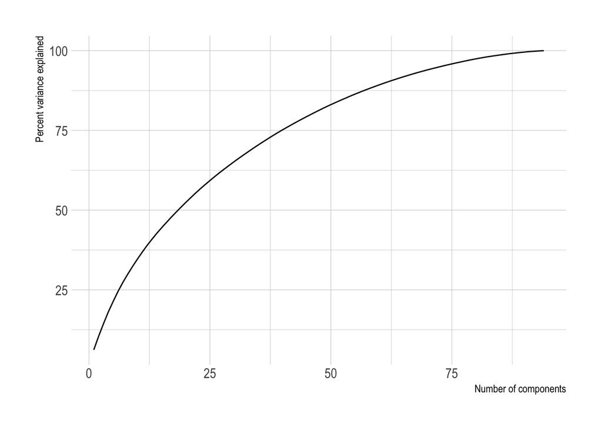

Amount of variance explained

The first 25 components explain 59.3 percent of the variance.